# Regression Project

Alim Ray

10/25/2015

# Executive Summary

Using the mtcars data included in RStudio, I have been asked to answer the folowing questions. Is an automatic or manual transmission better for MPG? Quantify the MPG difference between automatic and manual transmissions?

# Setting up data

Reading mtcars data and adding cylinder and transmission factors. Making transmission a factor variable will allow me to determine the marginal differences between manual and automatic transmissions when creating a linear regression.

# Expolaratory Analysis

Looking at the linear regression between mpg and transmissions only yields the following model.

Intercept = 17.1473684

Slope = 7.2449393

This shows a positive correlation before adjustments. I then looked at number of cylinders and weight because I believed they would effect the model. Below is a pairs plot of mpg, transmission, number of cylinders, and weight.

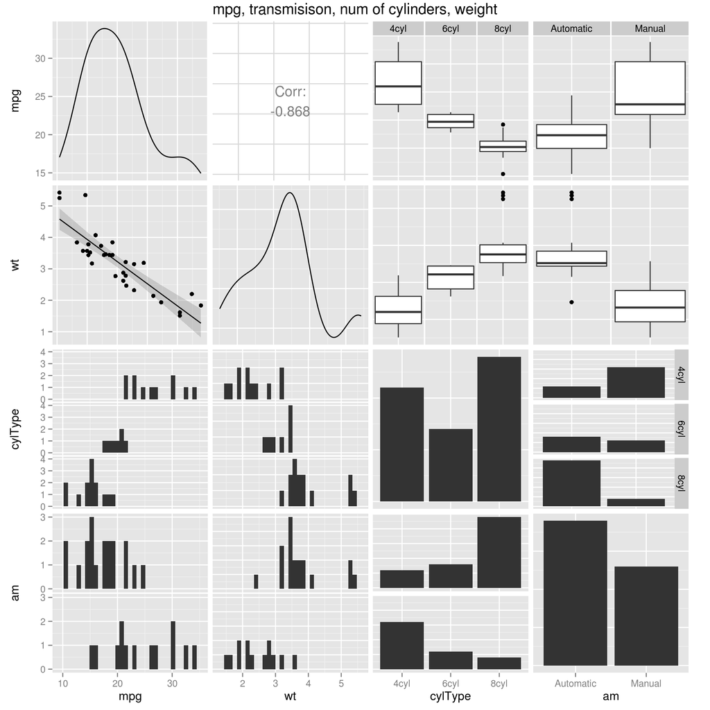

## Cylinders and Weight

Cell 1,3 of this graph is a box and whisker plot which shows that as number of cylinders increase, mpg decreases. Cell 2,1 also shows that as weight increases, mpg decreases. I checked the correlation between weight and cylinders and got 0.7824958. Since these data are highly correlated, I decided to remove weight from the model.

## Displacement and Horsepower

Engine displacement is the volume of an engine’s cylinders. This is directly correlated to the number of cylinders (correlation = 0.9020329) and was removed from the model. Horsepower is also a function of cylinders (correlation = 0.8324475) and was excluded from the model.

# Elimination of variables via ANOVA

Using the rest of the variables (and transmission + number of cylinders), I created five linear models that I tested using ANOVA.

```r
everything <- lm( mpg ~ am + drat + cylType, cars)
everything2 <- lm( mpg ~ am + drat + cylType + qsec, cars)
everything3 <- lm( mpg ~ am + drat + cylType + qsec + vs, cars)
everything4 <- lm( mpg ~ am + drat + cylType + qsec + vs + gear, cars)
everything5 <- lm( mpg ~ am + drat + cylType + qsec + vs + gear + carb, cars)
anova(everything, everything2, everything3, everything4, everything5)
```

```
## Analysis of Variance Table
##
## Model 1: mpg ~ am + drat + cylType
## Model 2: mpg ~ am + drat + cylType + qsec
## Model 3: mpg ~ am + drat + cylType + qsec + vs
## Model 4: mpg ~ am + drat + cylType + qsec + vs + gear
## Model 5: mpg ~ am + drat + cylType + qsec + vs + gear + carb
##   Res.Df    RSS Df Sum of Sq      F Pr(>F)
## 1     27 264.32
## 2     26 259.83  1     4.494 0.5205 0.4779
## 3     25 256.61  1     3.217 0.3726 0.5476
## 4     24 250.87  1     5.740 0.6647 0.4233
## 5     23 198.59  1    52.279 6.0547 0.0218 *
## ---
## Signif. codes:  0 '***' 0.001 '**' 0.01 '*' 0.05 '.' 0.1 ' ' 1
```

The qsec, v/s, and number of gears are shown to have high P-values (all > 0.4). Removing these fields, the final model is transmission, rear axle ratio, number of cylinders, and number of carburetors.

# Conclusion

```r
finalM <- lm( mpg ~ am + drat + cylType + carb, cars)
confInt <- summary(finalM)$coefficients[2,1] + c(-1,1) * summary(finalM)$coefficients[2,2] * qt(0.975, df = finalM$df)
```

Using the final model the coefficient for manual transmission is 3.5736741. Since this is positive, the effect of manual transmission on miles per gallon is positive. with a confidence interval of 0.4904621 to 6.656886 is also the average mpg increase when using a manual transmission.